# INLA package for R

Taddele, Tian, Regina

12:28 09 November 2015

### Implementing INLA

The following are required to perform INLA  
a) The GMRFLib-library  
b) The INLA package for `R`

Downloading, installing and loading the INLA package

Model Specification in the INLA package

Assume the following model: $\begin{split} y & \sim \pi(y|\lambda)\\ \eta & = g(\lambda) = \beta_{0} + \beta_{1}x_1 + \beta_{2}x_2 + f(x_3) \end{split}$ where $x_{1}, x_{2}$ are covariates with linear effect  
$\beta_{i}\sim N(0,\tau_{1}^{-1})$  
$x_3$ can be spatial effect, random effect, etc  
$f_{1},f_{2},... \sim N(0,Q_{f}^{-1}(\tau_2))$

The model is specified in R through a formaula, similar to the one used in the glm routine:

The $f()$ function is used to specify non-linear effects in the model.

Examples of the implemented model are:

- `iid1: random effects
- `rw1` `rw2` `arl`: smooth effect of covariates or time effect
- `seasonal`: seasonal effect
- `besag`: spatial effect (CAR model)
- `generic`: user defined precision matrix

Main functions of the INLA package

- *f()*: helps define non linear effects in the model specification
- *inla()*: performs bayesian analysis of additive models
- *surv.inla()*: performs a bayesian analysis of some survival models
- additional functions of the INLA package
  1. *summary()*: produces a summary of the main results from a fitted model
  2. *plot()*: produces some plot from the fitted model

Some examples of usage of the INLA package

- mixed effect model
- model with time series component
- model with spatial component
- model with space-varying regression coefficients
- model for survival data

### Examples

The following examples are mearnt to give an overview of the range of application of the INLA methodology

## Example 1: Simulating observations and states from a first order DLM (Toy Example)

The observational and the system equations respectively of the model is given as: $\begin{split} y_{t} & =x_{t}+v_{t}, \ \ \ v_{t}\sim N(0,V), \ \ \ t=1,...,n \\ x_{t} & =x_{t-1}+w_{t}, \ \ \ w_{t}\sim N(0,W), \ \ \ t=2,...,n \end{split}$

Generic approach consists in equating to zero the system equation $0=x_{t}-x_{t-1}+w_{t}, \ \ \ w_{t}\sim N(0,W), \ \ \ t=2,...,n$

```r
set.seed(123456)

W = 0.5
V = 1.0
n = 100
x0 = 0.00
w  = rnorm(n,0,sqrt(W))
v  = rnorm(n,0,sqrt(V))
x  = y = rep(0,n)                # a place holder for the x and y vector times
x[1] = x0   + w[1]               # system equations (state/latent parameters)
y[1] = x[1] + v[1]               # observational equations
for (t in 2:n){
  x[t] = x[t-1] + w[t]
  y[t] = x[t]   + v[t]
}
m = n-1

# building the augmented model
Y <- matrix(NA, n+m, 2)         # matrix for storing the actual and fake observations
Y[1:n,     1] <- y              # actual observations are stored in the first column
Y[1:m + n, 2] <- 0              # faked observations (assuming zero values) are in the second column
```

```r
i  <- c(1:n, 2:n)              # indices for  the states x_t
j  <- c(rep(NA,n), 2:n -1)     # indices for x_{t-1}
w1 <- c(rep(NA,n), rep(-1,m))  # weights for x_{t-1}
l  <- c(rep(NA,n), 2:n)        # indices for the perturbation terms w_t
w2 <- c(rep(NA,n), rep(-1,m))  # weights for w_t
```

## Formulating the model

The states, $x_t$, (indexed by `i`) follow a Gaussian distribution with a fixed and low log-precision (-10). The $x_{t-1}$ terms (indexed by `j`) are modeled as a copy of the $x_t$ terms. The perturbations, $w_t$, (indexed by `l`) follow a Gaussian distribution with unknown log-precision.

```r
# formulation with default hyperprior
formula1 <- Y ~ f(i, model="iid", initial=-10, fixed=T) +
  f(j, w1, copy="i") +
  f(l, w2, model ="iid") -1

# formulation with informative hyperprior
formula2 <- Y ~ f(i, model="iid", initial=-10, fixed=TRUE) +
                f(j, w1, copy="i") +
                f(l, w2, model="iid", param=c(4, 1.2)) -1

# formulation with vague hyperprior
formula3 <- Y ~ f(i, model="iid", initial=-10, fixed=TRUE) +
  f(j, w1, copy="i") +
  f(l, w2, model="iid", param=c(0.01, 0.003)) -1
```

Fitting the model

Two different Gaussian likelihoods are defined (for the actual and faked observations) in the family statement. The list in “control.family” statement defines the parameters for the log-precisions of the actual and faked observations, respectively. Here, default values are assumed in the first case, whereas a high and fixed value (10) is defined for the log-precision in the second case

```r
# default prior
r1 <- inla(formula1, data = data.frame(i,j,w1,w2,l),
           family = rep("gaussian", 2),
           control.family = list(list(), list(initial=10, fixed=T)),
           control.predictor=list(compute=TRUE))

# informative prior
r2 <- inla(formula2, data = data.frame(i,j,w1,w2,l),
           family = rep("gaussian", 2),
           control.family = list(list(param=c(4,2)), list(initial=10, fixed=T)),
           control.predictor=list(compute=TRUE))

# vague prior
r3 <- inla(formula3, data = data.frame(i,j,w1,w2,l),
           family = rep("gaussian", 2),
           control.family = list(list(param=c(0.01, 0.005)), list(initial=10, fixed=T)),
           control.predictor=list(compute=TRUE))

# elapsed time (seconds)
r1$cpu.used
```

```
##  Pre-processing    Running inla Post-processing           Total
##       0.2383053       1.1327665       0.0653851       1.4364569
```

```r
r2$cpu.used
```

```
##  Pre-processing    Running inla Post-processing           Total
##      0.18412733      1.07516527      0.06033921      1.31963181
```

```r
r3$cpu.used
```

```
##  Pre-processing    Running inla Post-processing           Total
##      0.18256783      1.08887696      0.05917454      1.33061934
```

```r
# summary() function to inspect our results
summary(r1)
```

```
##
## Call:
## c("inla(formula = formula1, family = rep(\"gaussian\", 2), data = data.frame(i, ",  "    j, w1, w2, l), control.predictor = list(compute = TRUE), ",  "    control.family = list(list(), list(initial = 10, fixed = T)))" )
##
## Time used:
##  Pre-processing    Running inla Post-processing           Total
##          0.2383          1.1328          0.0654          1.4365
##
## The model has no fixed effects
##
## Random effects:
## Name   Model
##  i   IID model
## l   IID model
## j   Copy
##
## Model hyperparameters:
##                                          mean     sd 0.025quant 0.5quant
## Precision for the Gaussian observations 1.237 0.2935     0.7606    1.203
## Precision for l                         1.863 0.6394     0.8952    1.770
##                                         0.975quant  mode
## Precision for the Gaussian observations      1.907 1.139
## Precision for l                              3.369 1.597
##
## Expected number of effective parameters(std dev): 138.19(8.077)
## Number of equivalent replicates : 1.44
##
## Marginal log-Likelihood:  -1728.89
## Posterior marginals for linear predictor and fitted values computed
```

```r
#summary(r2)
#summary(r3)

#names() function to see the list of variable names produced in the model
#names(r1)
```

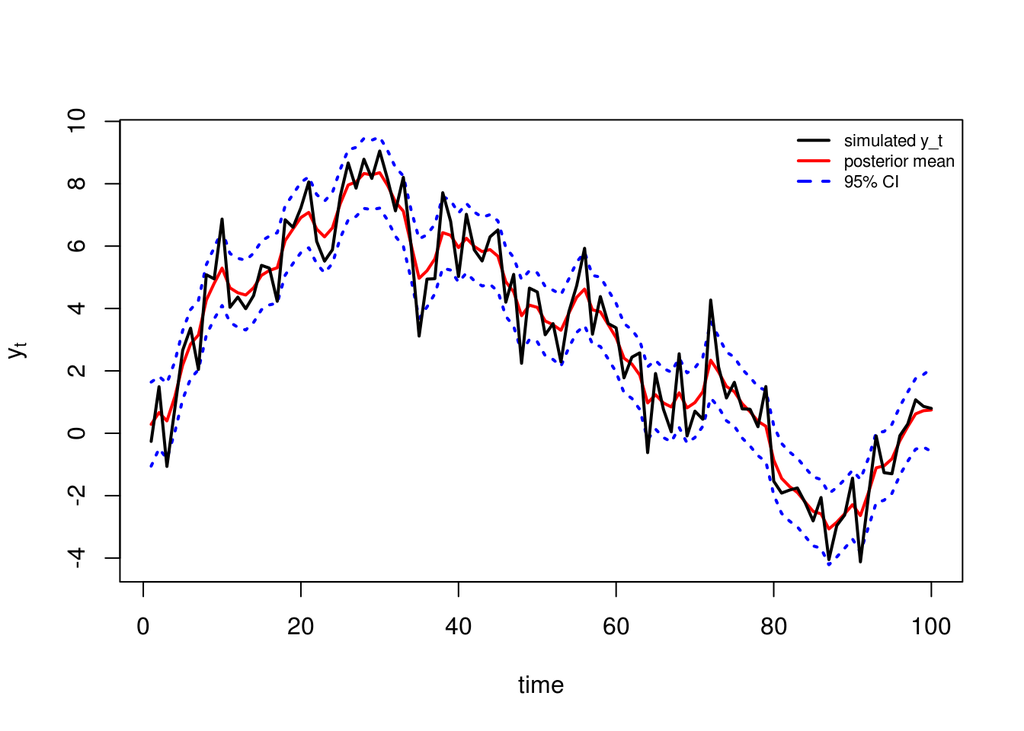

```r
# graph for observations (y)
#par(mfrow=c(1,1), mar=c(5,6.5,2,1), mgp=c(4,1,0),cex.axis=2,cex.main=2,cex.lab=3)
rang <- range(r1$summary.fitted.values[1:n, 3:5], y)
plot(r1$summary.fitted.values[1:n,1], type="l",
     ylim=rang, col="red", xlim=c(1,n),ylab=expression(y[t]),xlab="time",lwd=2)
lines(r1$summary.fitted.values[1:n,3], col="blue", lty=3,lwd=2)
lines(r1$summary.fitted.values[1:n,5], col="blue", lty=3,lwd=2)
lines(y[1:n],lwd=2)
legend("topright", legend=c("simulated y_t","posterior mean","95% CI"), col=c("black", "red","blue"),lty=c(1,1,2),lwd=c(2,2,2),bty="n",cex=0.7)
```

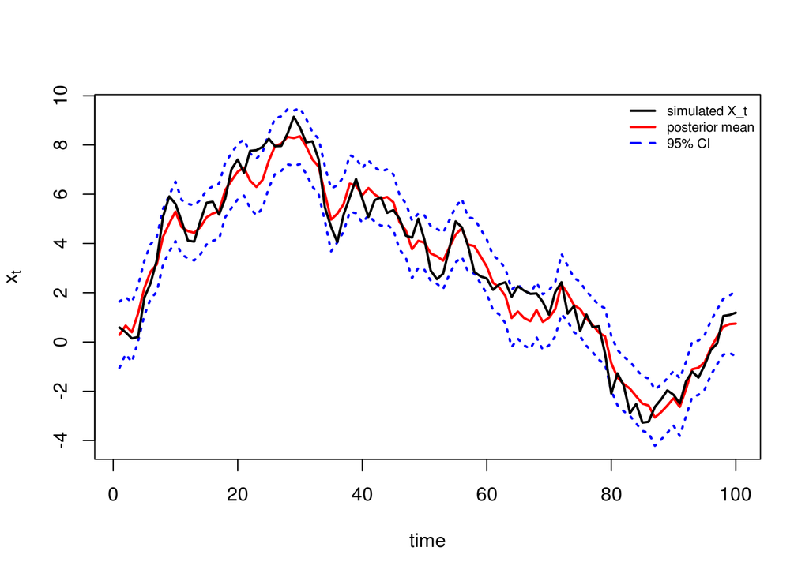

```r
#title("a toy example")

# graph for states (x)
#par(mfrow=c(1,1), mar=c(5,6.5,2,1), mgp=c(4,1,0),cex.axis=2,cex.main=2,cex.lab=3)
rang <- range(r1$summary.random[[1]][1:n, 4:6], x)
plot(r1$summary.random[[1]][1:n,2], type="l",
     ylim=rang, col="red", xlim=c(1,n),ylab=expression(x[t]),xlab="time",lwd=2)
lines(r1$summary.random[[1]][1:n,4], col="blue", lty=3,lwd=2)
lines(r1$summary.random[[1]][1:n,6], col="blue", lty=3,lwd=2)
lines(x[1:n],lwd=2)
legend("topright", legend=c("simulated X_t","posterior mean","95% CI"), col=c("black", "red","blue"),lty=c(1,1,2),lwd=c(2,2,2),bty="n",cex=0.7)
```

```r
#title("a toy example")
```

```r
# summary of posterior hyperparameters
# -------------------------------------
r1$summary.hyperpar
```

```
##                                             mean        sd 0.025quant
## Precision for the Gaussian observations 1.236761 0.2934669  0.7605837
## Precision for l                         1.862708 0.6394453  0.8951916
##                                         0.5quant 0.975quant     mode
## Precision for the Gaussian observations 1.203117   1.906657 1.138657
## Precision for l                         1.770021   3.369514 1.597122
```

```r
r2$summary.hyperpar
```

```
##                                             mean        sd 0.025quant
## Precision for the Gaussian observations 1.236664 0.2662660  0.7954477
## Precision for l                         1.949322 0.5868783  1.0298380
##                                         0.5quant 0.975quant     mode
## Precision for the Gaussian observations 1.209115   1.836911 1.156163
## Precision for l                         1.873491   3.310085 1.731614
```

```r
r3$summary.hyperpar
```

```
##                                             mean        sd 0.025quant
## Precision for the Gaussian observations 1.216084 0.2920713  0.7418966
## Precision for l                         1.727878 0.5882910  0.8392137
##                                         0.5quant 0.975quant     mode
## Precision for the Gaussian observations 1.182720   1.882979 1.118998
## Precision for l                         1.641345   3.120877 1.480612
```

Plotting the results for posterior marginal of the hyperparameters

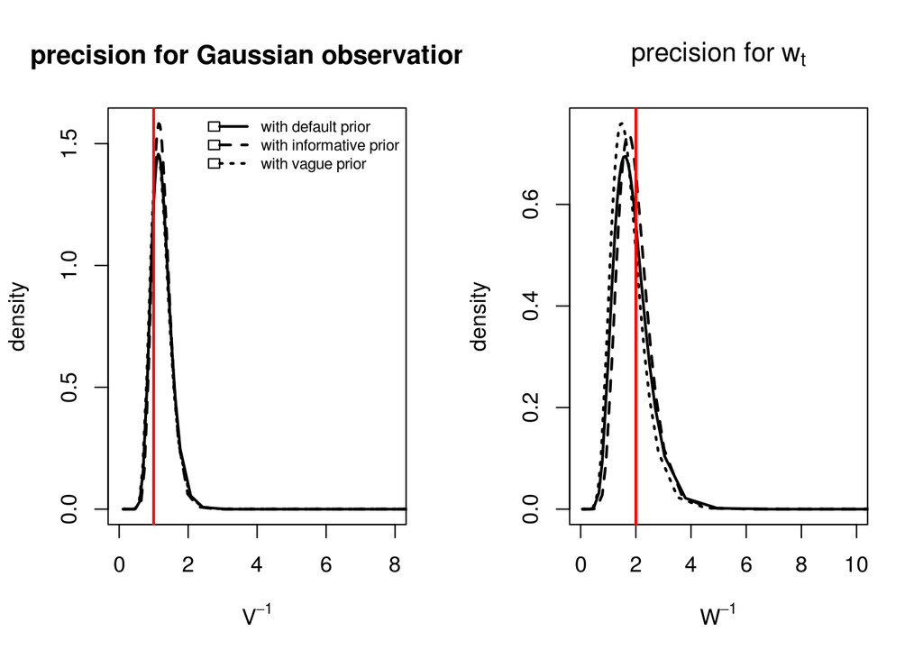

```r
# marginal posterior densities for precision parameters
# -----------------------------------------------------
par(mfrow=c(1,2))
#par(mfrow=c(1,1), mar=c(5,6.5,2,1), mgp=c(4,1,0),cex.axis=2,cex.main=2,cex.lab=3)
rang=range(r1$marginals.hyperpar[[1]][,2],r2$marginals.hyperpar[[1]][,2],r3$marginals.hyperpar[[1]][,2])
plot(r1$marginals.hyperpar[[1]], type="l", lwd=2,lty=1, xlab=expression(V^-1), main="precision for Gaussian observations", ylab="density",xlim=c(0,8),ylim=rang)  # precision of V
lines(r2$marginals.hyperpar[[1]],lwd=2,lty=2)
lines(r3$marginals.hyperpar[[1]],lwd=2,lty=3)
abline(v=1/V,col=2, lwd=2)
legend("topright",4,0.8, legend=c("with default prior","with informative prior","with vague prior"), lty=c(1,2,3),lwd=c(2,2,2),bty="n",cex=0.7)
#par(mfrow=c(1,1), mar=c(5,6.5,2,1), mgp=c(4,1,0),cex.axis=2,cex.main=2,cex.lab=3)
rang=range(r1$marginals.hyperpar[[2]][,2],r2$marginals.hyperpar[[2]][,2],r3$marginals.hyperpar[[2]][,2])
plot(r1$marginals.hyperpar[[2]], type="l", lwd=2, xlab=expression(W^-1), main=expression(paste("precision for",~ w[t])), ylab="density",xlim=c(0,10),ylim=rang)  # precision of W
lines(r2$marginals.hyperpar[[2]],lwd=2,lty=2)
lines(r3$marginals.hyperpar[[2]],lwd=2,lty=3)
abline(v=1/W,col=2, lwd=2)
```

## Example 2: A GLMM with over-dispersion

This is an example of GLMM with binomial likelihood where the random effects are used to model within group extra variation. The data concern the proportion of seeds that germinated on each of $m = 21$ plates arranged in a 2x2 factorial design with respect to seed variety and type of root extract. The model is given as $y_i|\eta_i \sim Binomial(n_i,p_i)$ where $y_i$ is the number of germinating seeds(vn:r), $n_i$ the total number of seeds (vn: n) and $p_i=logit^{-1}\eta_i$ is the unkwon probability of germinating, $i=1,...,m$. The fitted model is: $\eta_i=\beta_0 + \beta_1x_{1i}+\beta_2x_{2i}+\beta_3x_{1i}x_{2i}+f(u_i)$

Specifying our model

```r
formula = r ~ x1*x2 + f(plate, model="iid", param=c(1,0.001))
```

Running our model in INLA

```r
data(Seeds)      # loading the Seed data into R
head(Seeds,3)    # to view the first three rows of the Seed data
```

```
##    r  n x1 x2 plate
## 1 10 39  0  0     1
## 2 23 62  0  0     2
## 3 23 81  0  0     3
```

```r
mod.seeds = inla(formula, data=Seeds, family="binomial",Ntrials=n)
```

There is no need to specify the parameters for our prior distribution since we are using the default Gamma prior with $a=1$ and $b=0.001$.

Calling the $summary()$ function to inspect our reseults

```r
#options(digits=9)
summary(mod.seeds,digits=9)
```

```
##
## Call:
## "inla(formula = formula, family = \"binomial\", data = Seeds, Ntrials = n)"
##
## Time used:
##  Pre-processing    Running inla Post-processing           Total
##      0.13008428      0.02883005      0.03162146      0.19053578
##
## Fixed effects:
##                   mean        sd 0.025quant   0.5quant 0.975quant
## (Intercept) -0.5570261 0.1282025 -0.8109764 -0.5562895 -0.3073726
## x1           0.1427884 0.2259237 -0.3026776  0.1434077  0.5844150
## x2           1.3209200 0.1806272  0.9687514  1.3200345  1.6776519
## x1:x2       -0.7804195 0.3104659 -1.3894274 -0.7806367 -0.1707743
##                   mode kld
## (Intercept) -0.5547940   0
## x1           0.1446693   0
## x2           1.3182656   0
## x1:x2       -0.7810484   0
##
## Random effects:
## Name   Model
##  plate   IID model
##
## Model hyperparameters:
##                       mean     sd 0.025quant 0.5quant 0.975quant  mode
## Precision for plate 718.88 818.65      21.31   449.11    2902.80 39.16
##
## Expected number of effective parameters(std dev): 4.351(0.3969)
## Number of equivalent replicates : 4.826
##
## Marginal log-Likelihood:  -71.90
```

Assume we are interested in the posterior mean and standard deviation of the variance parameter $\sigma_{\mu}^2=1/\tau_{\mu}$, this can be done by selecting the appropriate posterior marginal from the *inla()* function:

```r
#names(mod.seeds) # can be used to view the various outputs produced by the inla() function
prec.marg=mod.seeds$marginals.hyperpar$`Precision for plate` #produces the individual precision values
#m1=inla.expectation(function(x) 1/x, prec.marg)     #not working
m1=mean(1/prec.marg[,1])
#m2=inla.expectation(function(x) (1/x)^2, prec.marg) #not working
m2=mean((1/prec.marg[,1])^2)
sd=sqrt(m2-m1^2)
print(c(mean=m1, sd=sd))
```

```
##      mean        sd
##  2.252712 11.649304
```

One can sample from the posterior densities. A sample of size 1000 from the posterior $\tilde{\pi}(\beta_1|y)$ can be obtained as:

```r
dens = mod.seeds$marginals.fixed$x1
sample = inla.rmarginal(1000,dens)
```

### Example 3: Childhood undernutrition in Zambia: Spatial analysis

Three different spatial models are considered to analyze the Zambia data. The authors study childhood undernutrition in 57 regions of Zambia. A total of $n_d = 4847$ observation are included in the data set. Stunting for child $i = 1,...,n_d$ is determined using a $Z$ score defined as: $Z_i = \dfrac{AI_i - MAI}{\sigma}$ where: $AI$ is the child’s anthropometric indicator, $MAI$ is the median of the reference population and $\sigma$ refers to the deviation of the standard population Covariates include age of the child ($age_i$),the body mass index of the child’s mother ($bmi_i$), the district the child lives in ($s_i$). $Z_i$ (vn: hazstd) is assumed to be conditionally independent Gaussian random variables with unknown mean $\eta_i$ and unknown precision $\tau_z$

Model 1: Assumption: all covariates have linear effect $\eta_i=\mu + {\bf z}_i^T \beta + f_s(s_i) + f_u(s_i)$

Model 2: Assumption: age of child is smooth but not linear $\eta_i=\mu + {\bf z}_i^T \beta + f_1(age_i)+ f_s(s_i) + f_u(s_i)$

Model 3: Assumption: Effect of bmi is linear but possess different slope for different regions $\eta_i=\mu + {\bf z}_i^T \beta + f_1(age_i)+ bmi_i f_2(s_i)$

```r
##load the data set
data(Zambia)
##load map
g = system.file("demodata/zambia.graph", package="INLA")
# add one column for the unstructured spatial effect
Zambia$distr.unstruct  =  Zambia$district

## define formula for the model
formula= hazstd ~  edu1 + edu2 + tpr + sex + bmi + agc +
  f(district, model="besag", graph = g) +
  f(distr.unstruct, model="iid")

# model
mod  =  inla(formula, data = Zambia, family = "gaussian",
              control.compute = list(dic = TRUE, cpo=TRUE))
summary(mod)
```

```
##
## Call:
## c("inla(formula = formula, family = \"gaussian\", data = Zambia, control.compute = list(dic = TRUE, ",  "    cpo = TRUE))")
##
## Time used:
##  Pre-processing    Running inla Post-processing           Total
##          0.5290       7322.8702          0.5983       7323.9975
##
## Fixed effects:
##                mean     sd 0.025quant 0.5quant 0.975quant    mode kld
## (Intercept) -0.0209 0.0995    -0.2161  -0.0209     0.1743 -0.0209   0
## edu1        -0.0625 0.0270    -0.1154  -0.0625    -0.0096 -0.0625   0
## edu2         0.2321 0.0472     0.1394   0.2321     0.3247  0.2321   0
## tpr          0.0971 0.0222     0.0535   0.0970     0.1408  0.0969   0
## sex         -0.0591 0.0134    -0.0854  -0.0591    -0.0329 -0.0591   0
## bmi          0.0231 0.0043     0.0146   0.0231     0.0315  0.0231   0
## agc         -0.0150 0.0008    -0.0166  -0.0150    -0.0135 -0.0150   0
##
## Random effects:
## Name   Model
##  district   Besags ICAR model
## distr.unstruct   IID model
##
## Model hyperparameters:
##                                             mean        sd 0.025quant
## Precision for the Gaussian observations     1.16 2.370e-02      1.114
## Precision for distr.unstruct            17009.52 1.764e+04   1036.500
## Precision for district                     28.32 1.391e+01     11.512
##                                         0.5quant 0.975quant     mode
## Precision for the Gaussian observations     1.16      1.207    1.159
## Precision for distr.unstruct            11694.99  63483.360 2749.422
## Precision for district                     24.98     64.181   19.847
##
## Expected number of effective parameters(std dev): 32.63(4.362)
## Number of equivalent replicates : 148.53
##
## Deviance Information Criterion (DIC) ...: 13074.80
## Effective number of parameters .........: 34.52
##
## Marginal log-Likelihood:  -6644.38
## CPO and PIT are computed
##
## Posterior marginals for linear predictor and fitted values computed
```

```r
plot(mod)
```

[output not shown]

```r
##MOD1
formula.mod1 = hazstd ~  agc + edu1 + edu2 + tpr + sex + bmi +
  f(district, model="besag", graph = g, param = c(1,0.01)) +
  f(distr.unstruct, model="iid", param = c(1,0.01))


##MOD2
formula.mod2 = hazstd ~ edu1 + edu2 + tpr + sex + bmi +
  f(agc, model = "rw2") +
  f(district, model="besag", graph = g, param = c(1,0.01)) +
  f(distr.unstruct, model="iid", param = c(1,0.01))


##MOD3
formula.mod3 = hazstd ~ edu1 + edu2 + tpr + sex +
  f(agc, model = "rw2") +
  f(district, bmi, model = "besag", graph = g, param = c(1,0.01), constr = FALSE)
```

```r
##run the three models
mod1  =  inla(formula.mod1, data = Zambia, control.family = list(initial = 1),
              control.inla = list(h=1e-4),
              control.compute = list(dic = TRUE, cpo=TRUE),
              verbose = F)

mod2  =  inla(formula.mod2, data = Zambia, control.family = list(initial = 1),
              control.inla = list(h = 1e-4),
              control.compute = list(dic = TRUE,cpo=TRUE),
              verbose = F)

mod3  =  inla(formula.mod3,data = Zambia, control.family = list(initial = 1),
              control.inla = list(h = 1e-4),
              control.compute = list(dic = TRUE,cpo=TRUE),
              verbose = F)
plot(mod1)
plot(mod2)
plot(mod3)

a<-summary(mod1)
b<-summary(mod2)
c<-summary(mod3)
##compute the log-score
log.score1 = -mean(log(mod1$cpo$cpo))
log.score2 = -mean(log(mod2$cpo$cpo))
log.score3 = -mean(log(mod3$cpo$cpo))

##pit histogram
par(mfrow=c(3,1))
hist(mod1$cpo$pit,br=30)
hist(mod2$cpo$pit,br=30)
hist(mod3$cpo$pit,br=30)
```

```r
#comparison
#linear effect pamaeters in the three models for the Zambia data
a$fixed[,-7]#mod1
```

```
##                mean     sd 0.025quant 0.5quant 0.975quant    mode
## (Intercept) -0.0249 0.1005    -0.2222  -0.0249     0.1722 -0.0249
## agc         -0.0150 0.0008    -0.0165  -0.0150    -0.0135 -0.0150
## edu1        -0.0625 0.0270    -0.1154  -0.0625    -0.0096 -0.0625
## edu2         0.2299 0.0472     0.1372   0.2299     0.3225  0.2299
## tpr          0.1015 0.0224     0.0575   0.1015     0.1456  0.1015
## sex         -0.0594 0.0134    -0.0857  -0.0594    -0.0332 -0.0594
## bmi          0.0230 0.0043     0.0146   0.0230     0.0314  0.0230
```

```r
b$fixed[,-7]#mod2
```

```
##                mean     sd 0.025quant 0.5quant 0.975quant    mode
## (Intercept) -0.4302 0.0965    -0.6197  -0.4302    -0.2409 -0.4302
## edu1        -0.0614 0.0260    -0.1125  -0.0614    -0.0103 -0.0614
## edu2         0.2379 0.0456     0.1484   0.2379     0.3274  0.2379
## tpr          0.0915 0.0219     0.0486   0.0915     0.1345  0.0914
## sex         -0.0584 0.0129    -0.0838  -0.0584    -0.0331 -0.0584
## bmi          0.0215 0.0041     0.0134   0.0215     0.0297  0.0215
```

```r
c$fixed[,-7]#mod3
```

```
##                mean     sd 0.025quant 0.5quant 0.975quant    mode
## (Intercept) -0.3726 0.0965    -0.5620  -0.3726    -0.1834 -0.3726
## edu1        -0.0618 0.0261    -0.1130  -0.0618    -0.0107 -0.0618
## edu2         0.2337 0.0457     0.1440   0.2337     0.3233  0.2337
## tpr          0.1008 0.0235     0.0546   0.1008     0.1470  0.1008
## sex         -0.0589 0.0129    -0.0843  -0.0589    -0.0335 -0.0589
```

```r
# list of the hyperparameters in the three models for the Zambia data
a$hyperpar#mod1
```

```
##                                             mean      sd 0.025quant
## Precision for the Gaussian observations   1.1618  0.0237     1.1156
## Precision for distr.unstruct            125.6237 73.8382    39.0107
## Precision for district                   49.6288 27.0862    15.3690
##                                         0.5quant 0.975quant    mode
## Precision for the Gaussian observations   1.1617     1.2090  1.1615
## Precision for distr.unstruct            107.7072   316.8493 80.5136
## Precision for district                   43.7673   118.3019 33.6217
```

```r
b$hyperpar#mod2
```

```
##                                               mean        sd 0.025quant
## Precision for the Gaussian observations     1.2474    0.0256     1.1983
## Precision for agc                       12754.1296 8257.2322  2960.6561
## Precision for distr.unstruct              135.7111   81.8637    40.1349
## Precision for district                     45.0320   23.9554    14.6291
##                                           0.5quant 0.975quant      mode
## Precision for the Gaussian observations     1.2469     1.2986    1.2460
## Precision for agc                       10825.1266 33940.1468 7336.9298
## Precision for distr.unstruct              115.8051   348.2886   85.3103
## Precision for district                     39.8564   105.5613   31.0523
```

```r
c$hyperpar#mod3
```

```
##                                               mean        sd 0.025quant
## Precision for the Gaussian observations     1.2495    0.0255     1.1999
## Precision for agc                       12482.0584 7957.1022  2807.3401
## Precision for district                   1513.1612  319.7042   964.4039
##                                           0.5quant 0.975quant     mode
## Precision for the Gaussian observations     1.2493     1.3003    1.249
## Precision for agc                       10691.3527 32798.6260 7173.525
## Precision for district                   1487.9102  2214.9023 1443.301
```

```r
# list of the Expectected,standard deviation of the # of parameters in the three models for the Zambia data
compEn<-cbind(a$neffp,b$neffp,b$neffp)
colnames(compEn)=c("mod1","mod2","mod3")
#DIC, and log score
modelDIC<-c(a$dic$dic,b$dic$dic,c$dic$dic)
log.score = c(log.score1,log.score2,log.score3 )
compEn1<-rbind(compEn,modelDIC,log.score)
compEn1
```

```
##                                           mod1         mod2       mod3
## Expectected  number of parameters    37.507200    43.891800    43.8918
## Stdev of the number of parameters     3.677300     3.739800     3.7398
## Number of equivalent replicates     129.228400   110.430600   110.4306
## modelDIC                          13070.958600 12731.587200 12736.6729
## log.score                             1.348423     1.313421     1.3139
```

```r
# list of cpuused in the three models for the Zambia data
compcpu<-rbind(a$cpu.used,b$cpu.used,b$cpu.used)
rownames(compcpu)=c("mod1","mod2","mod3")
compcpu
```

```
##      Pre-processing Running inla Post-processing    Total
## mod1         0.2875      42.7281          0.5049  43.5205
## mod2         0.3214     134.1502          0.3573 134.8288
## mod3         0.3214     134.1502          0.3573 134.8288
```

```r
# list of log marginal-likelihood in the three models for the Zambia data
compMlik<-cbind(a$mlik,b$mlik,b$mlik)
colnames(compMlik)=c("mod1","mod2","mod3")
compMlik
```

```
##                                            mod1      mod2      mod3
## log marginal-likelihood (integration) -6638.245 -6472.676 -6472.676
## log marginal-likelihood (Gaussian)    -6638.274 -6472.754 -6472.754
```

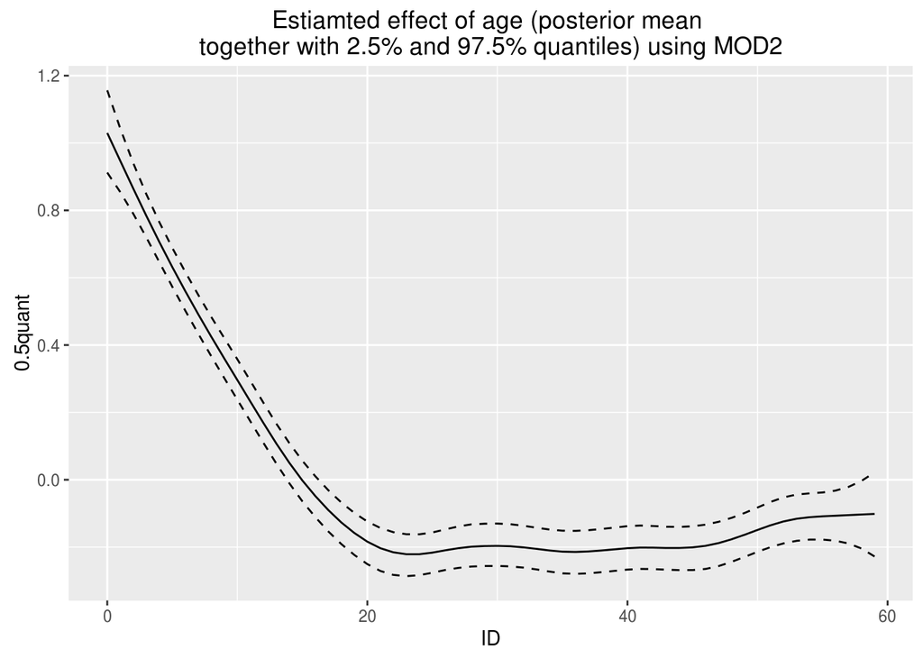

```r
#page12 Fig2.a Estiamted effect of age (posterior mean
#together with 2.5% and 97.5% quantiles) useing MOD2
library(ggplot2)

mydata2 <- as.data.frame(mod2$summary.random$agc)

ggplot(mydata2) +
  geom_line(aes(ID, `0.5quant`)) +
  geom_line(aes(ID, `0.025quant`), linetype="dashed") +
  geom_line(aes(ID, `0.975quant`), linetype="dashed") +
ggtitle("Estiamted effect of age (posterior mean
together with 2.5% and 97.5% quantiles) using MOD2")
```

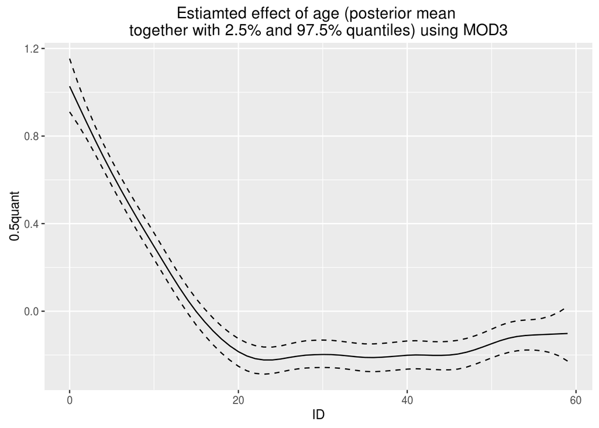

```r
#page12 Fig2.a Estiamted effect of age (posterior mean
#together with 2.5% and 97.5% quantiles) useing MOD3

mydata3 <- as.data.frame(mod3$summary.random$agc)

ggplot(mydata3) +
  geom_line(aes(ID, `0.5quant`)) +
  geom_line(aes(ID, `0.025quant`), linetype="dashed") +
  geom_line(aes(ID, `0.975quant`), linetype="dashed") +
  ggtitle("Estiamted effect of age (posterior mean
together with 2.5% and 97.5% quantiles) using MOD3")
```